# Written Assignment 03

# 7 Boxplot Visualizations

For a subset of the categorical and continuous features, perform **boxplot visualizations**. Comment on what you observed.

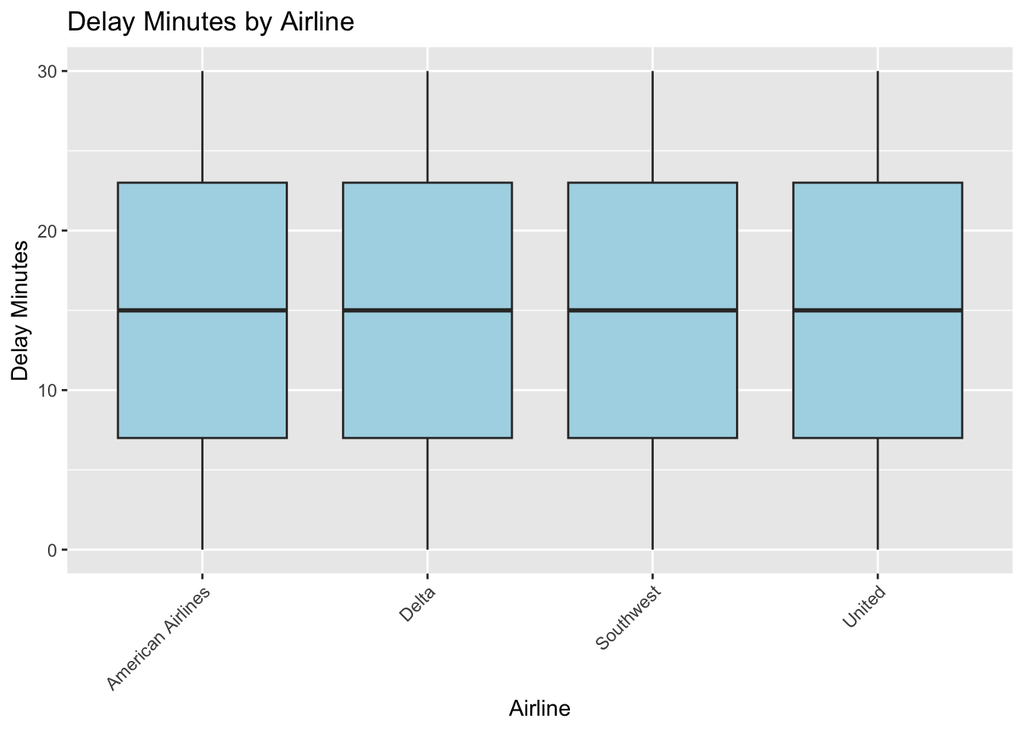

```r
ggplot(data, aes(x = Airline, y = DelayMinutes)) +
  geom_boxplot(fill = "lightblue") +
  labs(title = "Delay Minutes by Airline",
       x = "Airline",
       y = "Delay Minutes") +
  ylim(0, 30) +  # Adjust the y-axis to zoom in on shorter delays
  theme(axis.text.x = element_text(angle = 45, hjust = 1))  # Rotate x-axis labels for readability
```

The delay patterns across the airlines are very similar with no significant differences in median delay times or the range of delays. All airlines have mostly short delays with minimal outliers.

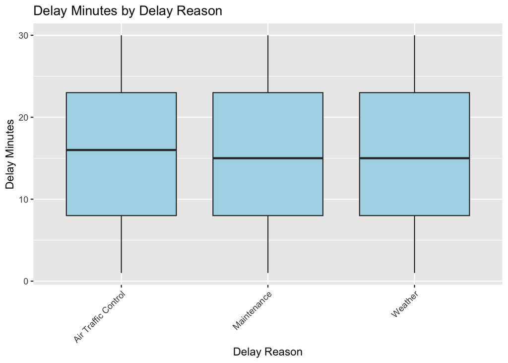

```r
# Filter out entries with missing delay reasons
filtered_data <- data %>% filter(DelayReason != "")

# Boxplot for DelayMinutes by DelayReason
ggplot(filtered_data, aes(x = DelayReason, y = DelayMinutes)) +
  geom_boxplot(fill = "lightblue") +
  labs(title = "Delay Minutes by Delay Reason",
       x = "Delay Reason",
       y = "Delay Minutes") +
  theme(axis.text.x = element_text(angle = 45, hjust = 1))  # Rotate x-axis labels for readability
```

This boxplot shows that delays for each delay reason tend to be around the same duration, with Air Traffic Control slightly edging out the other reasons. All three reason have similar variability in delay times, without many outliers.

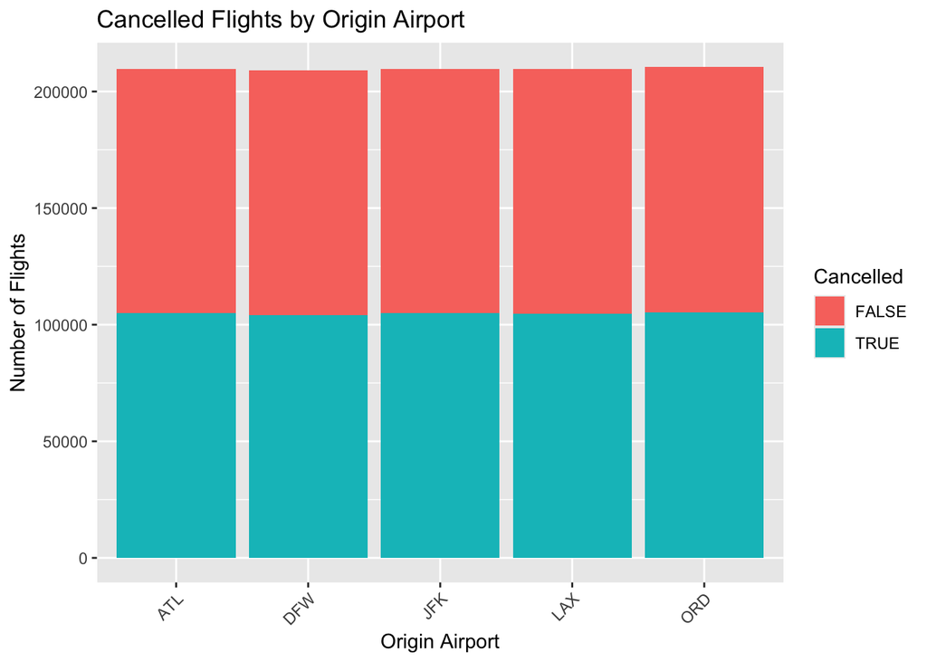

```r
# Stacked bar plot for Cancelled vs Origin Airport
ggplot(data, aes(x = Origin, fill = as.factor(Cancelled))) +
  geom_bar(position = "stack") +
  labs(title = "Cancelled Flights by Origin Airport",
       x = "Origin Airport",
       y = "Number of Flights",
       fill = "Cancelled") +

  theme(axis.text.x = element_text(angle = 45, hjust = 1))  # Rotate x-axis labels for readability
```

Cancellations are widespread and significant across all origina airports, with no airport having a huge red bar.